# L08 Coords

Data Visualization (STAT 302)

Author

JULIANNA WANG

Published

April 26, 2024

## Overview

The goal of this lab is to use an alternative coordinate system in `ggplot2` to build a plot.

## Dataset

We’ll be using the `mod_nba_adv_stats_2023_24.txt` dataset — add to your project’s `/data` subdirectory. The `mod_nba_adv_stats_2023_24_codebook.txt` provides a quick description of the variables in the dataset — suggest adding it to the `/data` subdirectory as well.

```r
# load package(s)
library(tidyverse)

# load data
nba <- read_delim(file = "data/mod_nba_adv_stats_2023_24.txt", delim = "|")
keys <- read_delim(file = "data/mod_nba_adv_stats_2023_24_codebook.txt", delim = ": ")
```

## Exercise

Using the `mod_nba_adv_stats_2023_24.txt` dataset we will try to recreate/approximate the plot type featured in the [FiveThirtyEight](http://fivethirtyeight.com/) article [Kawhi Leonard Is The Most Well-Rounded Elite Shooter Since Larry Bird](http://fivethirtyeight.com/features/kawhi-leonard-is-the-most-well-rounded-elite-shooter-since-larry-bird/) for any player of your choice for the 2023-2024 season.

**Goal**

### Start with data wrangling

When data wrangling we will need a helper function for creating the quartiles for players. Additionally, it will be useful to exclude players that played less than 10 games or played less than 5 minutes a game. That is, we only want to include “qualified” players.

```r
# Returns quartile rank
quartile_rank <- function(x = 0:99) {
  # Set quartile
  quart_breaks <- c(
    -Inf,
    quantile(x,
      probs = c(.25, .5, .75),
      na.rm = TRUE
    ),
    Inf
  )
  cut(x = x, breaks = quart_breaks, labels = FALSE)
}
```

**Important**

**Add comments to** the code below where indicated. The added comments should concisely describe what the following line(s) of code do in the data wrangling process

**Solution**

```r
# Graphical data
nba_graph_dat <- nba |>
  # filters players with at least 10 games, at least 5 minutes played per game
  filter(g >= 10, mp / g >= 5) |>
  # create variables for each player's statistic rank
  mutate(
    ts_quant = quartile_rank(ts_percent),
    trb_quant = quartile_rank(trb_percent),
    dbpm_quant = quartile_rank(dbpm),
    ast_quant = quartile_rank(ast_percent),
    usg_quant = quartile_rank(usg_percent)
  ) |>
  # pick players column and columns with "_quant" in their name
  select(player, contains("_quant")) |>
  # pivot data to long format
  pivot_longer(
    cols = -player,
    names_to = "variable",
    values_to = "value"
    ) |>
  # orders data by player name
  arrange(player)
```

### Build the plot

*Hints:*

- Image width is 8 in, height is 10 in — use code chunk yaml
- center the image output — use code chunk yaml
- shrink size down for display to 50% width — use code chunk yaml
- All added text, except title, is done with `annotate()`
- set `axis.text` to blank in theme
- size 3 and 5 could be useful

**Solution**

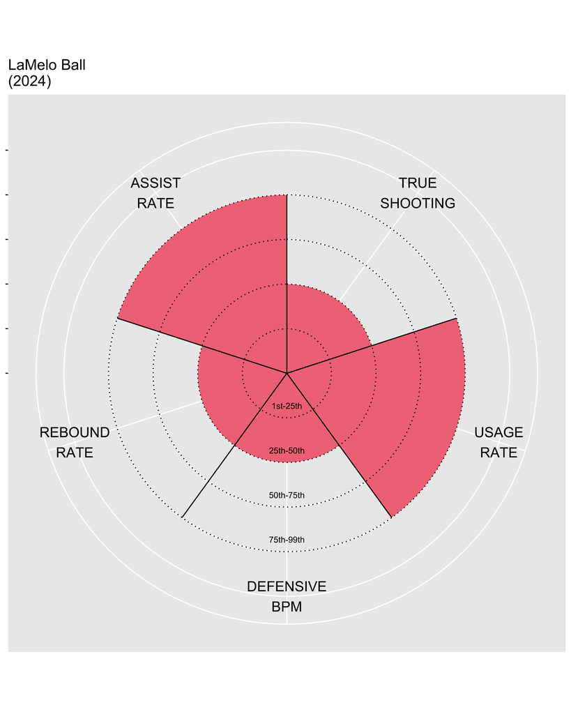

```r
# annotation data
labels <- c('TRUE\nSHOOTING', 'USAGE\nRATE', 'DEFENSIVE\nBPM', 'REBOUND\nRATE', 'ASSIST\nRATE')
bar_values <- c('1st-25th', '25th-50th', '50th-75th', '75th-99th')

player_name <- 'LaMelo Ball'

nba_graph_dat |> # use annotations to get the text
  filter(player == player_name) |>
  ggplot(aes(x = variable, y = value)) +
  geom_col(width = 1, fill = '#F07786') +
  # black lines
  geom_segment(aes(x = c(0.5, 1.5, 2.5, 3.5, 4.5), y = 0, yend = 4)) +
  # dotted lines
  geom_hline(yintercept = 1:4, linetype = 'dotted') +
  scale_y_continuous(expand = c(0,0)) +
  scale_x_discrete(
    limits = c('ts_quant', 'usg_quant', 'dbpm_quant', 'trb_quant', 'ast_quant'),
    expand = c(0,0)
  ) +
  ggtitle('LaMelo Ball \n(2024)') +
  theme(
    axis.text = element_blank(),
    axis.title = element_blank(),
    plot.title = element_text(size = 15)
  ) +
  # annotate for player stat labels
  annotate('text', x = seq_along(labels), y = 5, label = labels, size = 5) +
  # annotate for percentile labels
  annotate('text', x = 3, y = 1:4, label = bar_values, size = 3, vjust = -1.5) +
  coord_polar()
```

## Challenge

**Important**

Challenge is optional for all students, but we recommend trying them out!

**Solution**